# HW3

賴冠維

2020/11/1

## (1)

## (2)

#### (a)

先對$X_i$進行標準化,產生$Z_i$,  
並且對$Y_i$進行去中心化，產生$\widetilde{Y_i}$

首先固定$\lambda$為0.01，再利用glmnet函式估計Ridge Regression的OLS解， 分為$(x_i,y_i)$、$(z_i,\widetilde{Y_i})$兩組進行，  
求得參數**par1**及**par2**，分別代表$\widehat{\beta}$以及$\widetilde{\beta}$

```
## [1] -0.5588065  4.2011865 -1.2774805 -0.3433947  1.1131355 -3.7603531
```

```
## [1] -0.00000000000000005961494  3.74019025532804860745273
## [3] -1.25768969424733034756514 -0.32447521474505081062745
## [5]  1.18504269468205314375098 -3.98623379718136572336107
```

因為$z_i$不為方陣，因此在求反矩陣時使用$Moore-Penrose偽逆矩陣$。
藉此我們便可從$\widetilde{\beta}$推得$\widehat{\beta}$,矩陣表示式如下：
$$X\widehat{\beta} = Z\widetilde{\beta}$$
$$\widehat{\beta} = X^{-1}Z\widetilde{\beta}$$

- 表一為從$\widetilde{\beta}$推導$\widehat{\beta}$的數值
- 表二為上題從glmnet()函式所得到的參數。

```
##            [,1]
## [1,]  4.1991588
## [2,] -1.2218201
## [3,] -0.3430106
## [4,]  1.0933922
## [5,] -3.7700609
```

```
##      [,1]
## [1,] "Beta_hat 1: 4.20118651254475"
## [2,] "Beta_hat 2: -1.27748052895946"
## [3,] "Beta_hat 3: -0.34339467379893"
## [4,] "Beta_hat 4: 1.11313549138748"
## [5,] "Beta_hat 5: -3.76035306912517"
```

此外也可從$\widehat{\beta}$推得$\widetilde{\beta}$的數值，  
承列如下：

```
##            [,1]
## [1,]  3.7401903
## [2,] -1.2576897
## [3,] -0.3244752
## [4,]  1.1850427
## [5,] -3.9862338
```

```
##      [,1]
## [1,] "Beta_Standardize 1: 3.74019025532805"
## [2,] "Beta_Standardize 2: -1.25768969424733"
## [3,] "Beta_Standardize 3: -0.324475214745051"
## [4,] "Beta_Standardize 4: 1.18504269468205"
## [5,] "Beta_Standardize 5: -3.98623379718137"
```

#### (b)

產生$\lambda_i:2^{-10}、2^{-9}...、2^{4}、2^{5}$共16組

```
##                [,1]
##  [1,] 32.0000000000
##  [2,] 16.0000000000
##  [3,]  8.0000000000
##  [4,]  4.0000000000
##  [5,]  2.0000000000
##  [6,]  1.0000000000
##  [7,]  0.5000000000
##  [8,]  0.2500000000
##  [9,]  0.1250000000
## [10,]  0.0625000000
## [11,]  0.0312500000
## [12,]  0.0156250000
## [13,]  0.0078125000
## [14,]  0.0039062500
## [15,]  0.0019531250
## [16,]  0.0009765625
```

由於此題定義的Loss Function如下：
$$min \frac{1}{2N}\Sigma^{N}_{i=1}(y_i-\Sigma^p_{j=1}x_{ij}\beta_j)^2+\lambda\Sigma^j_{j=1}\beta^2_j$$

故一階導數為0之最小值，其矩陣表示式為：
$$\widehat{\beta}^{ridge}_\lambda = (\frac{1}{N}X^{T}X+2\lambda I_p)^{-1}\frac{1}{N}X^{T}Y$$
且上式X需要標準化，Y需去中心化，可得結果如下

1. 依不同的$\lambda_i$所求之$\widehat{\beta}(\lambda)$畫出Solution Path Line Plot

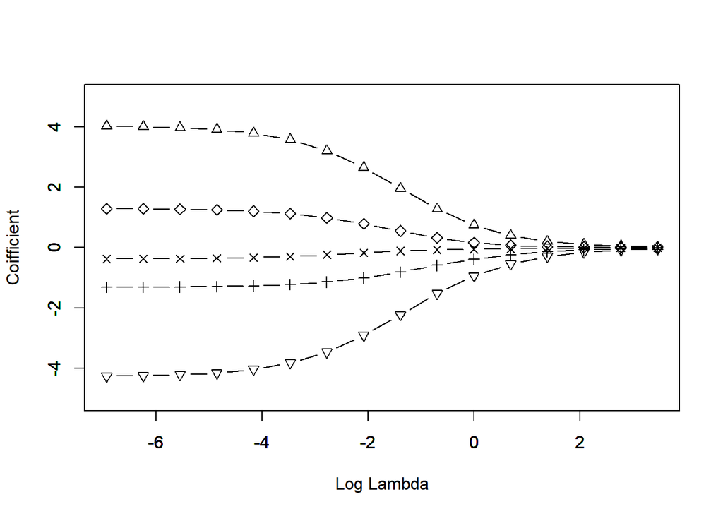

2. 列出從*$(2^{-10}...2^{5})$*之下的$\widehat{\beta}(\lambda)$

```
##           [,1]       [,2]       [,3]       [,4]       [,5]       [,6]
## [1,]  4.020300  4.0041486  3.9722278  3.9098700  3.7907745  3.5728162
## [2,] -1.312362 -1.3093520 -1.3033565 -1.2914645 -1.2680992 -1.2231561
## [3,] -0.376736 -0.3735725 -0.3673717 -0.3554547 -0.3334134 -0.2954987
## [4,]  1.290542  1.2844804  1.2725069  1.2491435  1.2046274  1.1235493
## [5,] -4.261262 -4.2454611 -4.2142277 -4.1531895 -4.0365239 -3.8226664
##            [,7]       [,8]       [,9]       [,10]       [,11]       [,12]
## [1,]  3.2033346  2.6513172  1.9648283  1.28366151  0.74709780  0.39976831
## [2,] -1.1407041 -1.0033481 -0.8092079 -0.58874990 -0.38835442 -0.23601979
## [3,] -0.2382756 -0.1688230 -0.1077309 -0.07128855 -0.05369614 -0.04079682
## [4,]  0.9874544  0.7880784  0.5489850  0.32561934  0.16494763  0.07368899
## [5,] -3.4589043 -2.9116415 -2.2218062 -1.52005123 -0.94257961 -0.54214434
##            [,13]       [,14]        [,15]        [,16]
## [1,]  0.20408642  0.10222344  0.050961069  0.025409120
## [2,] -0.13426479 -0.07262863 -0.037967456 -0.019442321
## [3,] -0.02785124 -0.01690186 -0.009424342 -0.004993725
## [4,]  0.03071533  0.01273554  0.005489593  0.002488339
## [5,] -0.29568199 -0.15556787 -0.080010647 -0.040609009
```

$\widehat{\beta}(2)$ 在Origin Scale下的估計值

```
##            [,1]
## [1,]  4.3202397
## [2,] -1.4257163
## [3,] -0.3573408
## [4,]  1.2204615
## [5,] -3.8767087
```

#### (c)

使用glmnet()函式所求給定在$\lambda_i$之下的$\widehat{\beta}(\lambda)$的估計值

```
##          [,1]       [,2]       [,3]       [,4]       [,5]       [,6]       [,7]
## V1  4.0354887  4.0342465  4.0321537  4.0277084  4.0187853  3.9998389  3.9629047
## V2 -1.3154439 -1.3154067 -1.3149106 -1.3138770 -1.3125249 -1.3081668 -1.3009412
## V3 -0.3797479 -0.3794963 -0.3791142 -0.3782932 -0.3766445 -0.3728343 -0.3655736
## V4  1.2960005  1.2954515  1.2945884  1.2927764  1.2889759  1.2822591  1.2685813
## V5 -4.2757784 -4.2744406 -4.2722708 -4.2678197 -4.2583968 -4.2407819 -4.2050531
##         [,8]       [,9]     [,10]      [,11]      [,12]       [,13]       [,14]
## V1  3.891004  3.7550071  3.509723  3.1032234  2.5158766  1.81736870  1.15729912
## V2 -1.287130 -1.2605472 -1.209400 -1.1171954 -0.9673876 -0.76427394 -0.54427435
## V3 -0.351754 -0.3267444 -0.284791 -0.2240416 -0.1544224 -0.09791823 -0.06660194
## V4  1.242014  1.1915913  1.100699  0.9514429  0.7405346  0.49950974  0.28633785
## V5 -4.135156 -4.0021456 -3.761532 -3.3606441 -2.7770164 -2.07197881 -1.38684773
##          [,15]       [,16]
## V1  0.65994053  0.34870677
## V2 -0.35245312 -0.21100990
## V3 -0.05096718 -0.03808681
## V4  0.14080939  0.06167905
## V5 -0.84498895 -0.47989915
```

將glmnet()所求之$\widehat{\beta}(\lambda)$畫出Solution Path Line Plot

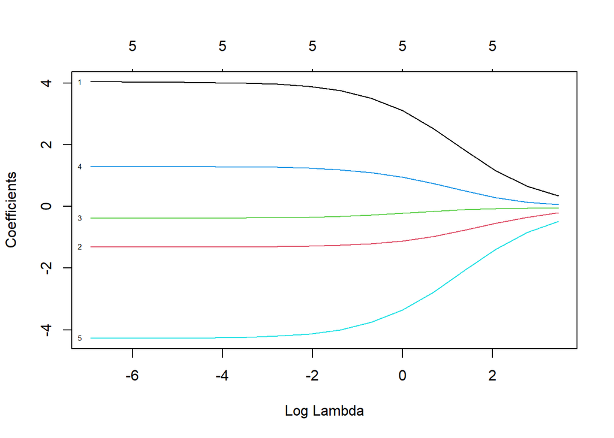

使用vignette()查閱glmnet套件的說明後發現，

glmnet的默認的分配為Gaussian，以下為glmnet所用Ridge Regression的Loss Function：
$$min \frac{1}{2N}\Sigma^{N}_{i=1}(y_i-\beta_0-x_i^{T}\beta)^2+\lambda[||\beta||^2_2/2]$$
與此題所使用的Loss Function 不相同，
$$min \frac{1}{2N}\Sigma^{N}_{i=1}(y_i-\Sigma^p_{j=1}x_{ij}\beta_j)^2+\lambda\Sigma^j_{j=1}\beta^2_j$$
因此兩者差異可能來自：
後面$\lambda$項差了一個除以2的部分，而導致我們自己求的矩陣解的$\lambda_i$效果為套件的2倍， 因此隨著$\lambda_i$的值增加兩者的差異擴大，也導致自行求的矩陣解收斂速度快於glmnet()

#### (d)

使用Cross Validation的方式計算模型在不同$\lambda_i$之下的表現，表現如下：  
可以發現不管是min或lse之下，都是5個參數，並未達到變數篩選的功能， 其原因可能來自我們使用模擬的隨機項，變數間並無意義上的差別。

```
##
## Call:  cv.glmnet(x = z, y = y_1, lambda = num, nfolds = 10, family = "gaussian",      alpha = 0)
##
## Measure: Mean-Squared Error
##
##     Lambda Measure    SE Nonzero
## min   0.25   32.50 4.682       5
## 1se   4.00   36.49 4.746       5
```

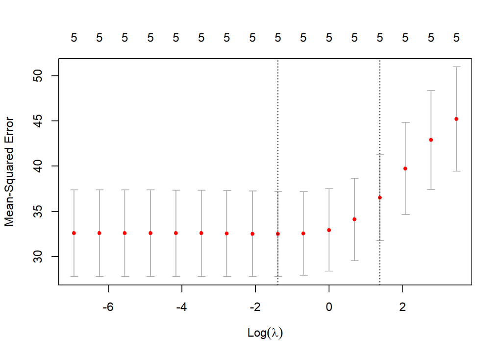

我們將資料以$(75\%,25\%)$分為Train、Test Set  
接著以$\lambda_{min}$及$\lambda_{lse}$ 配飾兩個$RidgeRegression$  
以Train Set 配飾模型，比較其預測Test Set 的SSE，借此衡量兩模型的表現。

兩個模型估計出不同的$\widehat{\beta_i}$

```
## 5 x 1 sparse Matrix of class "dgCMatrix"
##            s0
## V1  3.5223511
## V2 -2.3957434
## V3 -0.2242332
## V4  2.1627620
## V5 -4.4781497
```

```
## 5 x 1 sparse Matrix of class "dgCMatrix"
##            s0
## V1  1.9071403
## V2 -1.5158969
## V3 -0.2215735
## V4  0.9047308
## V5 -2.3901481
```

由此可見使用$\lambda_{lse}$的模型的SSE較小，表現較佳

```
## [1] "SSE of lambda.min: 1034.73466015926"
```

```
## [1] "SSE of lambda.lse: 851.897302170231"
```

但由Predict-Y Plot可見，圓圈為真實值，另兩個符號為預測值，表現皆不佳，無法有效預測Y。

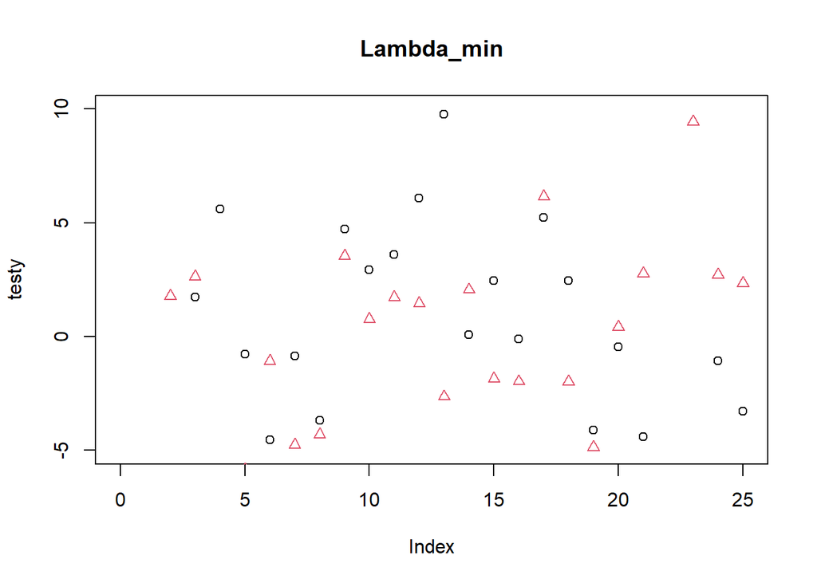

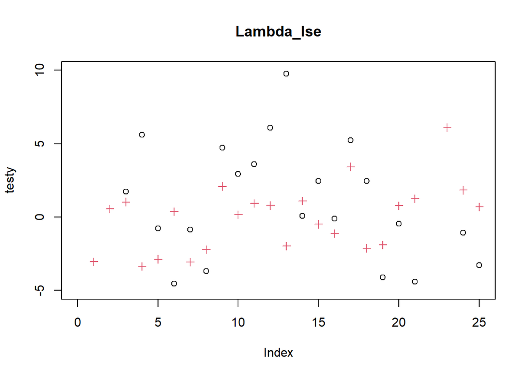